# Homework3

Neha Maddali

9/24/2021

```r
library(classdata)
library(ggplot2)
library(tidyverse)
data(ames)
```

## Question 1

Explore and explain what is the relationship between the sale price (y) and living area size (x). In your visualization, add a straight line with intercept at 20000 and slope equal to 100. Look at ?geom_abline, and in particular the examples. Remark on any patterns you find and the straight line.

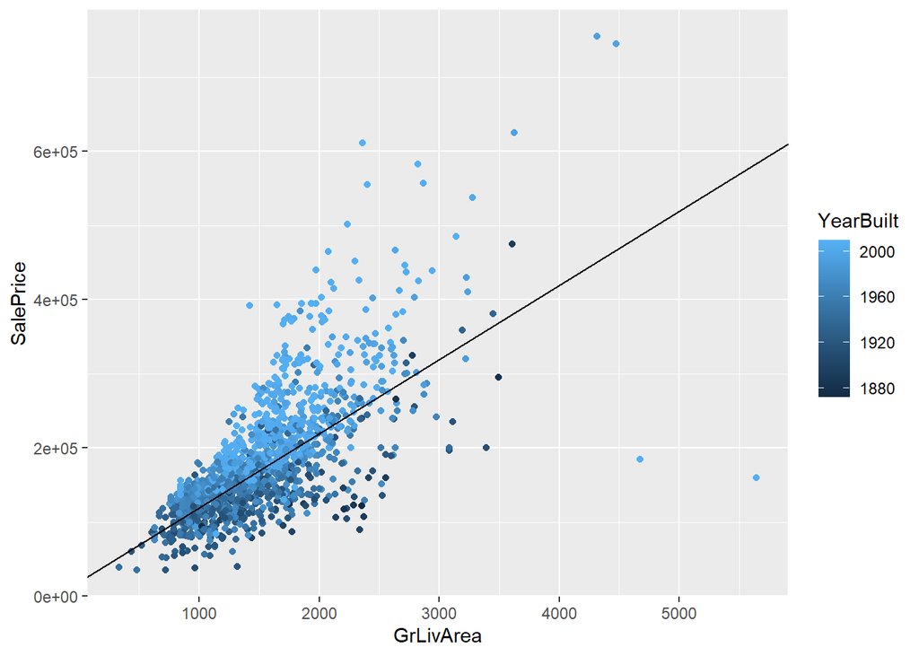

```r
p <- ggplot(ames, aes(x=GrLivArea, y=SalePrice, color=YearBuilt))+geom_point()
p + geom_abline(intercept=20000, slope=100)
```

**My Analysis** As the living area size increases, the sale price increases. As seen from the scatter plot, there is a heavy concentration of data points where the living area is 1000 to 2500l where the Sale Price is around 2e+5. The abline line shows that as living area size increases, so does the sale price.

## Question 2

Describe at least two types of anomalies in the previous plot. What do they mean?

**My Analysis** The really apparenent outliers of the previous graph are the two points below the regression line, closer to a 5000 living area size with around a 2e+5 Sale Price. The majority of the data points indicate that as living area increases, so does sale price. These two data points do not follow that trend. The lighter blue data points were mostly above the regression line indicating that the more recent built house had higher sale prices.

## Question 3

Visualize the number of sales by the overall condition. Make sure the conditions are ordered from the best to the worst. What do you find?

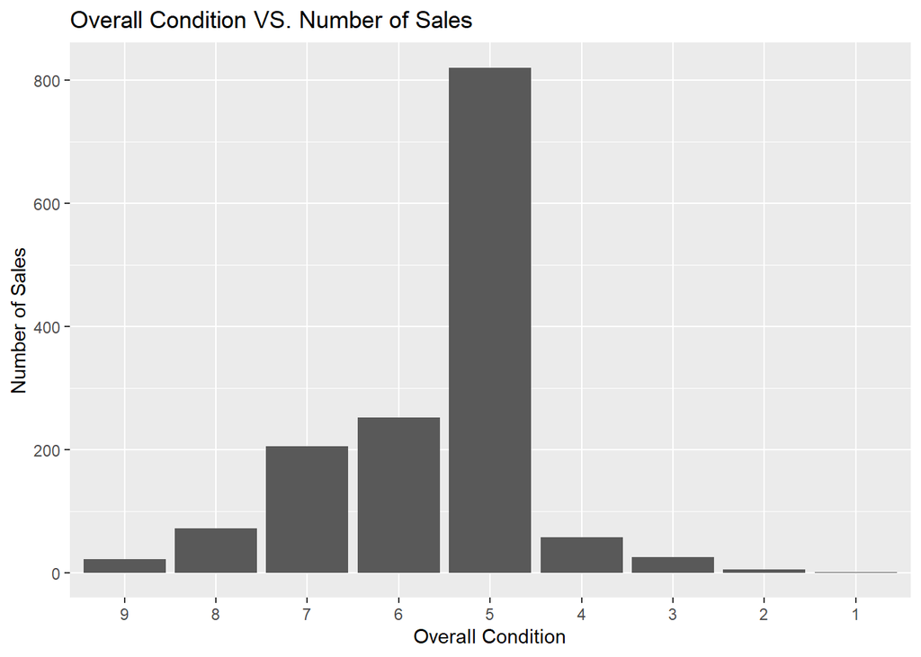

```r
ames$OverallCond <- factor(ames$OverallCond, levels = 9:1)
ggplot(ames, aes(x=OverallCond))+geom_histogram(stat = "Count")+labs(title = "Overall Condition VS. Number of Sales", x="Overall Condition",y="Number of Sales")
```

```r
summary(ames$OverallCond)
```

```
##   9   8   7   6   5   4   3   2   1
##  22  72 205 252 821  57  25   5   1
```

**My Analysis** With counting how many sales there are for each overall condition, it looks like there are the most sales with an overall condition of 5.

## Question 4

Introduce a variable houseAge into the data set which stands for the age of the house at the time when it was sold. How does the age of the house affect the sale price?

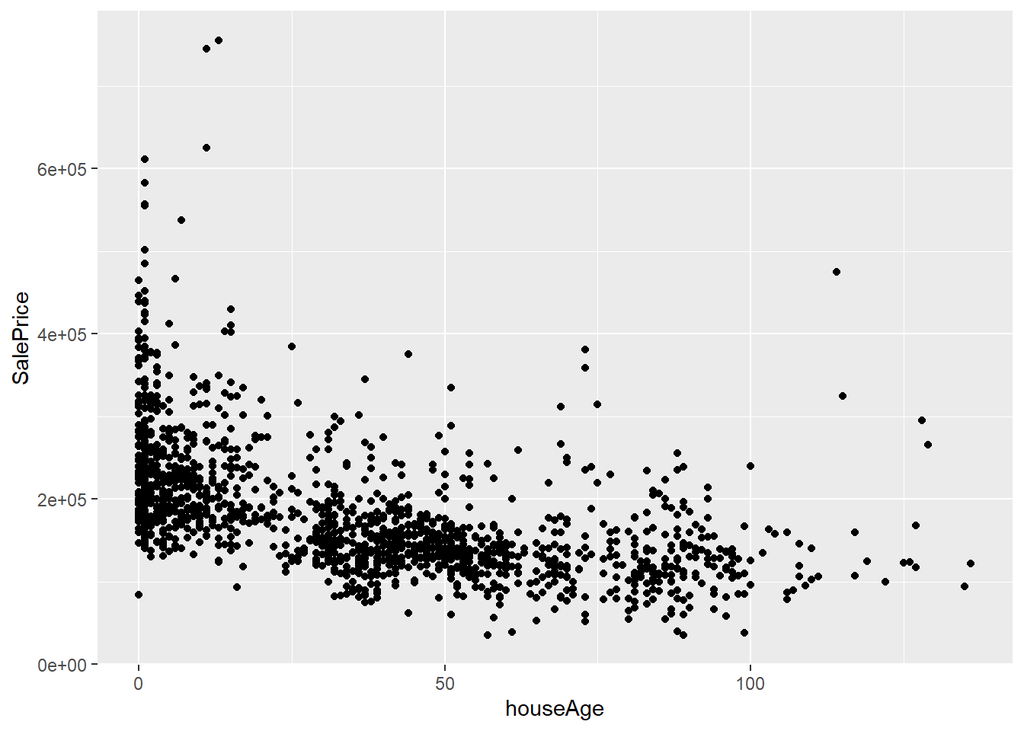

```r
houseAge <- ames$YrSold - ames$YearBuilt
#houseAge
p <- ggplot(ames, aes(x=houseAge, y=SalePrice))+geom_point()
p
```

**My Analysis** With first finding the houseAge using the YrSold and YearBuilt values of the dataset, I then conducted a ggplot scatter plot. The results show that as the house age increases, the sale price of the house decreases. As the house age was below 20, the sale price of the house was really high.

## Question 5

Were there more sales of nice houses or poor houses? Make sure to state your criterion for a house to be “nice” or otherwise “poor”. Choose an appropriate graph type.

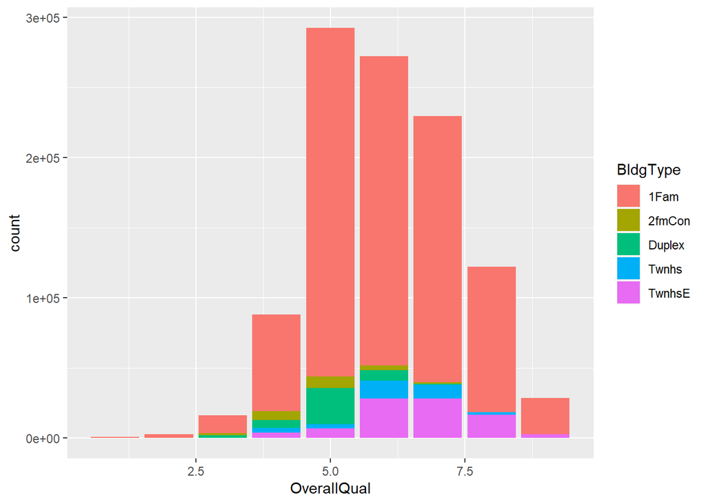

```r
building <- ames[ames$BldgType %in% c('1Fam','2fmCon','Duplex','Twnhs','TwnhsE'), ]
quality <- building[building$OverallQual %in% c(1,2,3,4,5,6,7,8,9), ]
ggplot(quality, aes(x=OverallQual, weight=Id, fill=BldgType))+geom_bar()
```

**My Analysis** My criterion for this problem is 1-4 is poor quality, 5-9 is nice quality. From creating the bar graph from above, there are the most sales for houses with an overall quality of 5 which is nice quality. The building type 1Fam has the most sales in general. Overall, there are more sales for nice houses compared to poor houses.

## Question 6

How do the neighborhood and the slope of property affect the relationship between sale price and year built? Focus on the neighborhoods of Brookside, Clear Creek, College Creek, and Somerset only. Find a visualization that incorporates all four variables. Interpret the result.

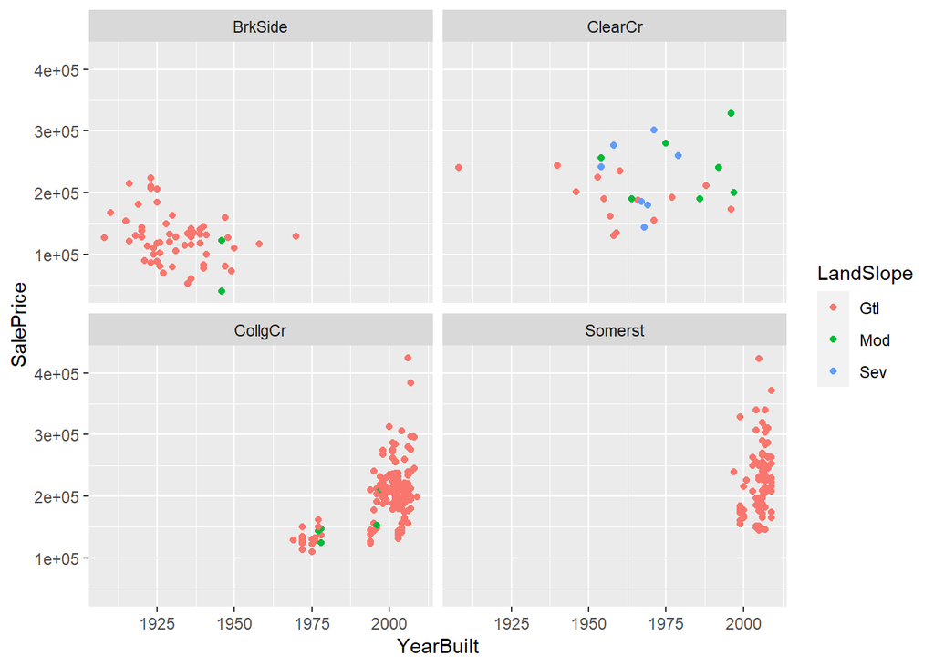

```r
dat<-ames[ames$Neighborhood%in%c('BrkSide','ClearCr','CollgCr','Somerst'), ]
ggplot(dat, aes(x=YearBuilt, y=SalePrice, colour = LandSlope)) + geom_point() + facet_wrap(~Neighborhood)
```

**My Analysis** From the graphs created, it looks like Somerset has majority Gtl land slope houses built in the early 2000s and onwards. Clear Creek has data points on all of the land slope showing almost a neutral like trend slope. College Creek is similar to Somerset in the sense that Gtl land slope houses were heavily built in 2000 and onwards. Brookside has many Gtl land slope houses built before the 1950s. It’s really hard to tell the affect neighborhood and slope of property have on the relationship between sale price and year built.

## Question 7

Create a side-by-side histogram showing the sales price for the different types of buildings. Comment on the result.

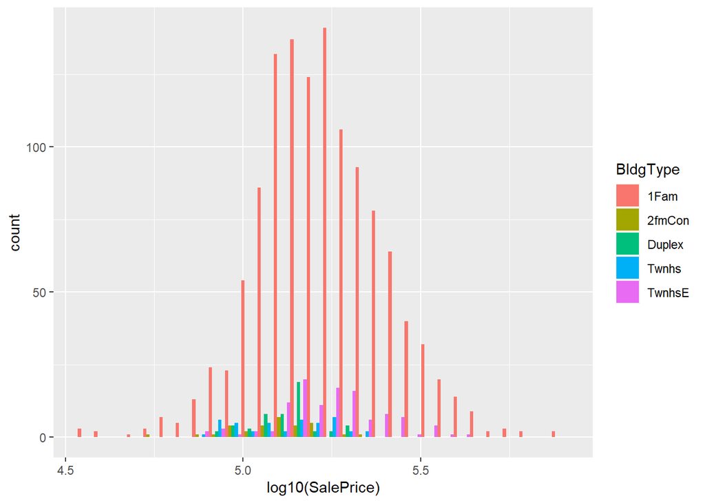

```r
s <- ames[ames$BldgType %in% c('1Fam','2fmCon','Duplex','Twnhs','TwnhsE'), ]
ggplot(s,aes(x=log10(SalePrice),fill=BldgType))+ geom_histogram(position="dodge",bins=30)
```

**My Analysis** With creating side-by-side histograms, 1Fam building type has the most sales. 2fmCon building type seems to have the least sale count of the five types of buildings.